# Análisis Encuesta de Caracterización Socioeconómica Nacional CASEN | Región del Bío-Bío

Héctor Garrido Henríquez

29/11/2017

En primer lugar, es recomendable antes de realizar cualquier análisis borrar todos los objetos que pueden estar guardados en sesiones de trabajo previas. Esto con el fin de evitar confundir al programa con el nombre de algún objeto ya utilizado, entre otras razones. Para ello utilizaremos la siguiente función

```r
rm(list=ls())
```

Esta función ha eliminado todos los objetos que previamente pueden haber estado guardados en el *environment* (una de las pestañas que aparecen arriba a la derecha en **Rstudio**). Note que si tipeamos lo siguiente

```r
ls()
```

```
## character(0)
```

Ha aparecido el mensaje *character(0)* esto quiere decir que el *environment* está vacío.

Pues bien, para trabajar con la encuesta CASEN necesitamos importar dicha base de datos hacia **R**. En general, este tipo de bases de datos se guardan en formatos más conocidos para el público en general, como Stata o SPSS, por lo que hemos de utilizar un paquete llamado *foreign* para importar ese tipo de objetos y poder trabajarlos con R.

```r
file.choose()
```

Una vez determinada la ubicación del archivo, procedamos a instalar el paquete *foreign*, de la siguiente forma

```r
install.packages("foreign")
```

Una vez instalado el paquete hemos de cargarlo, como es habitual, a través de *library*

```r
if (!require(foreign)) install.packages("foreign"); require(foreign)
```

```r
setwd("/home/hector/GoogleDriveUBB/OLR Ñuble - Observatorio laboral de Ñuble/Bases de datos/Encuesta de Caracterización Socioeconómica Nacional (CASEN)/")
casen<- read.spss("Casen 2015 SPSS.sav", use.value.labels = FALSE,
                  to.data.frame = FALSE)
```

Ahora, en su pestaña *environment* ha aparecido un objeto de nombre *casen*, el cual puede mirar, tipeando:

```r
View(casen)
```

Puede verificar la clase del objeto a través de la siguiente orden

```r
class(casen)
```

```
## [1] "list"
```

Para ver el listado de variables de la base de datos utilizaremos la siguiente orden

```r
names(casen)[1:10]
```

```
##  [1] "folio"       "o"           "id_vivienda" "region"      "provincia"
##  [6] "comuna"      "zona"        "hogar"       "tot_hog"     "tot_par"
```

sólo he pedido un número reducido de variables de la casen, pues tiene una cantidad enorme de ellas (por algo es la encuesta más importante del país), para hacerse una idea de ello tipee lo siguiente:

```r
dim(casen)
```

Para determinar el tamaño del objeto podemos tipear

```r
format(object.size(casen), units="MB")
```

```
## [1] "1611 Mb"
```

### Creación de un directorio de variables

Como ya hemos visto, al utilizar la orden *names* aparece el nombre de las variables de la encuesta, aunque dichos nombres no son muy informativos. Para tener una perspectiva más clara es necesario crear un directorio de variables. El directorio no será más que un nuevo *data.frame* en el que tendremos cada una de las variables y sus respectivas etiquetas.

Realizaremos lo siguiente:

```r
etiquetas <- attr(casen,"variable.labels") #Para extraer las etiquetas de las variables
diccionario.variables <- data.frame(var.name=names(casen),etiquetas) #Para hacer una tabla

casen = data.frame(casen)
```

Una vez creado el directorio ahora puede acceder a los nombres y “descripción” de cada una de las variables tipeando

```r
View(diccionario.variables)
```

## Probabilidades desiguales de selección y factores de expansión

Cuando analizamos datos desde una muestra es fundamental conocer el diseño muestral a través del cual se han recogido dichos datos. El más común de todos ellos es el **muestreo aleatorio simple** o MAS. Sin embargo, no todas las muestras, en especial las encuestas de hogares, son recolectados de esa manera. Para utilizar el MAS es necesario disponer de un marco muestral (o listado de las unidades a muestrear) que no siempre está disponible. En particular, en el caso chileno, no tenemos una lista actualizada de las personas que viven en cada hogar como para realizar un muestreo de esa naturaleza.

La encuesta CASEN, por tanto, tampoco está recogida bajo un esquema de MAS. Por lo tanto, lamento informarles que todos los métodos aprendidos durante la mayoría de los cursos de Estadística y Econometría no sirven para analizar directamente la encuesta, pues debemos utilizar variaciones de ellos.

La encuesta CASEN está recogida bajo un esquema de muestreo multietápico, en donde se estratifican las comunas en dos grupos: urbano y rural; y luego se seleccionan al azar conglomerados, los cuales usualmente son manzanas, y de estos conglomerados se seleccionan viviendas al azar (Para el lector interesado adjunto Informe de Diseño Muestral de la Encuesta). Note entonces que hay tres etapas involucradas: selección de estratos, selección de conglomerados (*unidad primaria de muestreo*) y selección de viviendas (*unidad secundaria de muestreo*).

En un muestreo multietápico el principal problema con el que debemos lidiar es que las probabilidades de selección de cada una de las unidades muestrales (en este caso, viviendas) no son iguales. Por ejemplo: cuando usted tiene una población de 1000 individuos y recoge una muestra de 100 individuos, la probabilidad de escoger a cada uno es de $100/1000=0.1$. De manera análoga, podemos pensar que cada individuo representa a 10 individuos (1/0.1), valor que denominaremos factor de expansión o peso. Como en un diseño muestral complejo las probabilidades de selección son desiguales, cada unidad observada en la muestra representa un número diferente de unidades en la población. Por ejemplo, tipee lo siguiente

```r
head(casen$expr,15)
```

```
##  [1] 104 104 104 104 104 104 104 104 104 104 104 104 104 104 104
```

```r
mean(casen$yautcorh)
```

```
## [1] 843258.4
```

```r
weighted.mean(casen$yautcorh, casen$expr)
```

```
## [1] 931794.2
```

> Por lo tanto, **siempre que trabajemos con una muestra compleja (es decir, que no ha sido obtenida según muestreo aleatorio simple) hemos de considerar los factores de expansión para generar estimaciones insesgadas**

## Diseño muestral complejo y precisión de los estimadores

Si bien el uso de los factores de expansión *elimina el problema de sesgo al realizar una estimación*, al trabajar con una muestra compleja es necesario también corregir los errores estándar para poder realizar inferencia estadísticamente válida.

En particular, en ciertos esquemos de muestreo se presenta el problema denominado **correlación intracluster**. El problema de la correlación intracluster puede ser entendido mejor a través de un ejemplo:

> Suponga que en la ciudad de Chillán, ha decidido llevar a cabo un muestreo por conglomerados, es decir, como no dispone de un listado de todas las personas de la ciudad, ha decidido seleccionar ciertos barrios al azar y encuestará todas las viviendas de ese barrio. El problema consiste en que las personas de determinados barrios tienen características muy similares entre sí. Por ejemplo, las personas que viven en el centro de la ciudad se parecen, las que lo hacen en la periferia también, mientras que las que viven en algún otro barrio, también se parecen. En términos estadísticos esto significa que existe correlación entre ellas, lo que en particular viola el principio de muestra aleatoria, es decir que las observaciones sean **igual e independientemente distribuidas**. Las observaciones ya no serán independientes entre sí. Esto, en términos concretos, implica que ahora **el error estándar de sus estimaciones estará sesgado**.

El tratamiento estadístico de estas situaciones es complicado y debido a que el curso no persigue dichos objetivos, no abordaremos en detalle la teoría estadística detrás de lo que acabamos de ilustrar. Sin embargo, en este apunte aprenderemos a utilizar el paqute **survey** de *R* el cual permite realizar cálculos estadísticos correctos al momento de trabajar con una muestra tomada bajo un esquema muestral complejo.

## Incorporando el diseño muestral complejo al análisis

Para que podamos trabajar correctamente en **R** con la encuesta **CASEN** debemos instalar en primer lugar el paquete *Survey* a través de la siguiente orden

```r
install.packages("survey")
```

Luego, naturalmente, cargarlo

```r
library(survey)
```

Para informar al programa cómo se ha seleccionado la muestra, y por tanto, realizar cálculo estadísticos correctos debemos utilizar los siguientes comandos

```r
options(survey.lonely.psu="adjust") #Para evitar clusters con una sola observación
design<-svydesign(ids=casen$varunit, strata=casen$varstrat, weights=casen$expr, nest=TRUE, data=casen)
```

Acabamos de crear un objeto llamado *design* el cual tiene los siguientes componentes:

- *id* indica la unidad primaria de muestreo, en nuestro caso dicha variable se llama *varunit* que no es más que un identificador de cada conglomerado en la muestra
- *weights* indica qué factor de expansión utilizaremos, en nuestro caso el factor de expansión regional (esto indica a cuántos individuos de la población representa cada individuo de la muestra)
- *nest* indica que aquellos conglomerados con pocas observaciones serán combinados.
- *data* indica cuál es la base de datos (data.frame) con el que estamos trabajando.

### Cálculo de la media para una variable continua

Dicho lo anterior, ahora podemos calcular el ingreso promedio de los hogares de la región a través de la siguiente orden

```r
svymean(casen$yautcorh, design)
```

```
##        mean    SE
## [1,] 931794 12457
```

- La función *svymean* permite calcular la media corrigiendo los errores estándar y considerando los factores de expansión.
- Note que en el argumento de la función hemos incluido al objeto *design*, con esto el paquete tiene toda la información necesaria para calcular correctamente la media.

La estimación coincide con la que realizamos anteriormente utilizando los factores de expansión, pero ahora además nos muestra el error estándar del estimador.

### Cálculo de una proporción para una variable categórica

Para calcular una proporción de manera correcta es necesario utilizar la orden

```r
svyciprop(~sexo=="hombre", design, method="logit")
```

```
##                               2.5% 97.5%
## sexo == "hombre" 2.58e-12 2.53e-12     0
```

Note que en el argumento de la función hemos incluido las siguientes elementos

### Gráfico de pastel

Vamos a realizar un gráfico de pastel para observar

```r
tabla.contrato<-svytable(~casen$o16, design)
tabla.contrato
```

```
## casen$o16
##       1       2       9
## 4204527 1652952     279
```

```r
tipo.contrato<-prop.table(tabla.contrato)*100
tipo.contrato
```

```
## casen$o16
##            1            2            9
## 71.777068974 28.218168111  0.004762914
```

[figure not shown]

Tipo de Contrato

```r
pie(tipo.contrato, labels=c("Plazo indefinido - 74.51%", "Plazo fijo - 25.28%", "ns/nr - 0.2%"),
    main="Tipo de contrato", family="Times", col=c("red", "blue", "green"))
```

#### Gráfica de pastel en tres dimensiones

Si la gráfica anterior no nos dejó del todo a gusto, podemos utilizar otro paquete llamado *plotrix*, el que - entre muchas otras cosas - permite hacer gráficas de tres dimensiones.

Instalemos el paquete

```r
install.packages("plotrix")
```

Carguemos el paquete

```r
library(plotrix)
```

Una vez cargado el paquete utilizaremos los siguientes comandos

[figure not shown]

```r
lbls<-c("Plazo indefinido - 74.51%", "Plazo fijo - 25.28%", "ns/nr - 0.2%")
pie3D(as.numeric(tipo.contrato), labels=lbls,
      explode=0.1,main="Tipo de Contrato ")
```

## El mercado del trabajo de la región

Para prácticar lo que hemos aprendido realizaremos varios ejemplos.

### Condición de Actividad

Veamos qué proporción de individuos se encontraban en cada condición de actividad durante el período de levantamiento de la encuesta

```r
cat.activ<-svytable(~casen$activ, design)
cat.activ
```

```
## casen$activ
##       1       2       3
## 7546055  608399 5823031
```

```r
prop.activ<-prop.table(cat.activ)*100
prop.activ
```

```
## casen$activ
##         1         2         3
## 53.987216  4.352707 41.660077
```

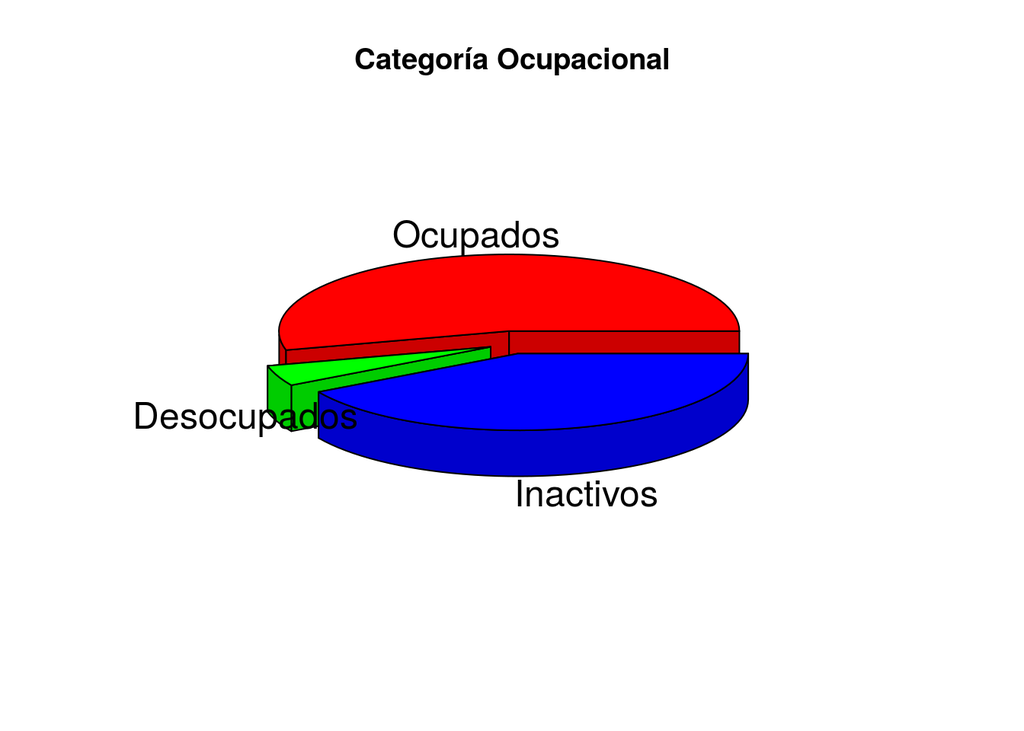

```r
lbls<-c("Ocupados", "Desocupados", "Inactivos")
pie3D(as.numeric(prop.activ), labels=lbls,
      explode=0.1,main="Categoría Ocupacional")
```

Si quisieramos una gráfica más sobria

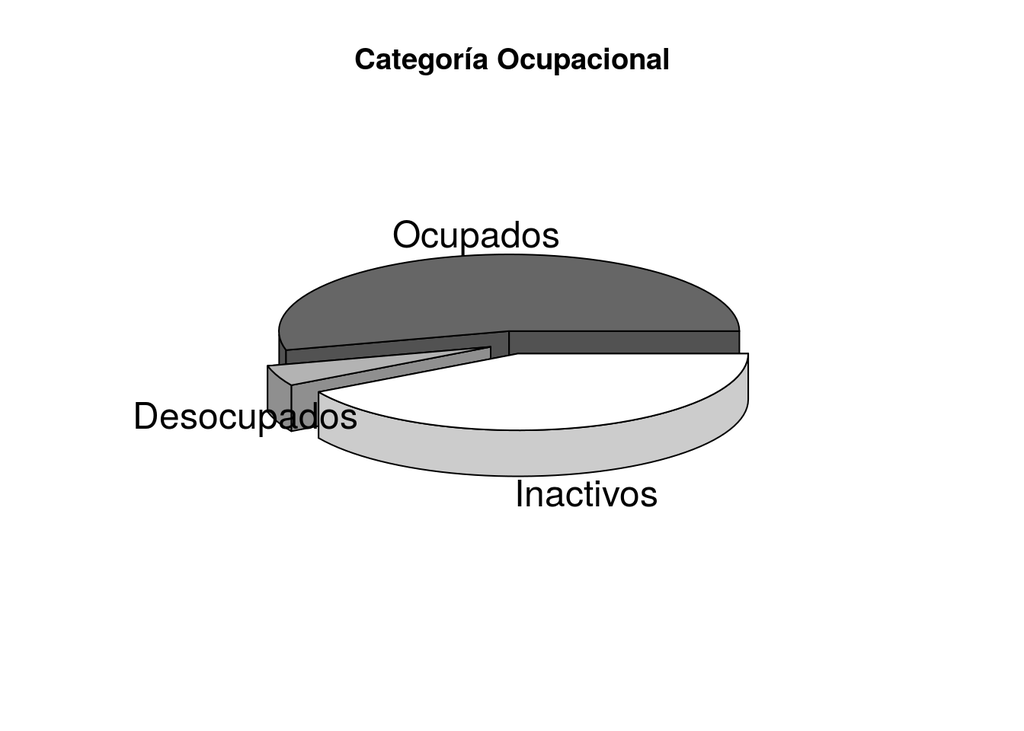

```r
pie3D(as.numeric(prop.activ), labels=lbls,
      explode=0.1,main="Categoría Ocupacional", col=gray(seq(0.4,1.0, length=3)))
```

#### Condición de actividad por sexo

A continuación analizaremos qué proporción de individuos se encuentra en cada condiciíon de actividad utilizando además la variable sexo. Para ello crearemos un objeto de manera muy similar al caso anterior

```r
cat.activ.sex<-svytable(~casen$activ+sexo, design)
cat.activ.sex
```

```
##            sexo
## casen$activ       1       2
##           1 4289229 3256826
##           2  311707  296692
##           3 1880011 3943020
```

```r
prop.activ.sex<-prop.table(cat.activ.sex)*100
prop.activ.sex
```

```
##            sexo
## casen$activ         1         2
##           1 30.686701 23.300515
##           2  2.230065  2.122642
##           3 13.450281 28.209796
```

Note que sólo hemos añadido *+sexo* a la formula anterior. Lo que nos ha arrojado una tabla de contingencia un poco más compleja, para graficar ésta tendremos que dividirla. Para ello conviene saber con qué tipo de objeto estamos trabajando

```r
class(cat.activ.sex)
```

```
## [1] "svytable" "xtabs"    "table"
```

Note que el objeto es de tres tipos *“svytable” “xtabs” “table”*. Nos interesa que sea de tipo *table* pues podemos trabajarlo como una matriz. Para determinar las características de esta matriz tipearemos

```r
dim(prop.activ.sex)
```

```
## [1] 3 2
```

Note que es un objeto de 3 filas y dos columnas, una columna de hombre y otra de mujeres, usaremos entonces cada objeto para hacer una gráfica diferente.

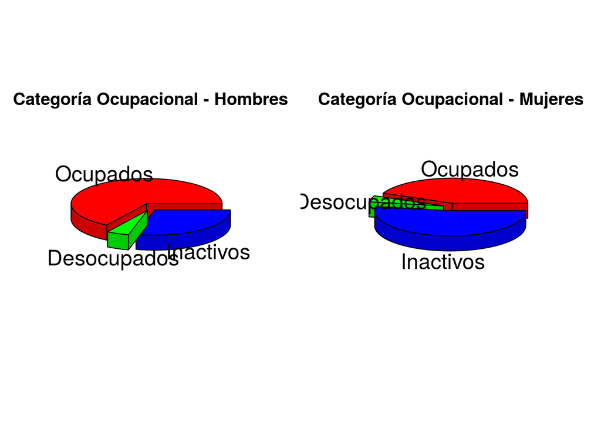

```r
par(mfrow=c(1,2))
lbls<-c("Ocupados", "Desocupados", "Inactivos")
pie3D(as.numeric(prop.activ.sex[,1]), labels=lbls,
      explode=0.1,main="Categoría Ocupacional - Hombres")
pie3D(as.numeric(prop.activ.sex[,2]), labels=lbls,
      explode=0.1,main="Categoría Ocupacional - Mujeres")
```

La gráfica anterior es de similares características a lo ya realizado. Fíjese, eso sí, que hemos hecho algunas cosas adicionales. utilizamos el comando *par(mfrow=c(1,2))* con esto indicamos que haríamos una matriz de gráficos de 1 fila y 2 columnas (e.g. si quisiera usar cuatro gráficos sería una matriz 2x2). En cada gráfico especificamos que columna utilizar de la tabla de proporciones anterior, la primera columna de hombres y la segunda de mujeres.

## Categoría ocupacional

Analicemos qué proporción de individuos se encuentra en cada categoría ocupacional en la región.

```r
cat.ocup<-svytable(~casen$o15, design)
cat.ocup
```

```
## casen$o15
##       1       2       3       4       5       6       7       8       9
##  204442 1452531  591706  196205 4720862   22263  251818   74904   32808
```

```r
prop.ocup<-prop.table(cat.ocup)*100
prop.ocup
```

```
## casen$o15
##          1          2          3          4          5          6
##  2.7087240 19.2450943  7.8397210  2.5995891 62.5483618  0.2949703
##          7          8          9
##  3.3364253  0.9924295  0.4346847
```

Quizá no sea tan buena idea construir un gráfica de pastel para esta variable, pues son demasiadas categorías. Construyamos en su lugar una gráfica de barras, para ello utilicemos el paquete *ggplot2*.

```r
library(ggplot2)

cat.ocup.grafico<-ggplot(subset(casen, !is.na(o15)), aes(factor(o15), weight=expr))+geom_bar()+ylab("Porcentaje")+xlab("Categoría Ocupacional")+coord_flip()+geom_text(aes(label =ifelse((..count..)==0,"",scales::percent((..count..)/sum(..count..)))), stat="count",colour="black")

cat.ocup.grafico
```

[output not shown]

```r
levels(casen$o15)<-c("Patrón o empleador", "Trabajador por cuenta propia","Empleado u obrero del sector público", "Empleado u obrero de empresas públicas", "Empleado u obrero del sector privado", "Servicio Doméstico puertas adentro", "Servicio Doméstico puertas afuera", "FF.AA. y del Orden", "Familiar no remunerado")
```

[figure not shown]

```r
if (!require(ggplot2)) install.packages("ggplot2"); require(ggplot2)
cat.ocup.grafico = ggplot(subset(casen, !is.na(o15)), aes(factor(o15), weight=expr))+ylab("Número de trabajadores")+xlab("Categoría Ocupacional")+geom_bar(fill="blue")+coord_flip()+geom_text(aes(label =ifelse((..count..)==0,"",scales::percent((..count..)/sum(..count..)))), stat="count",colour="black", vjust=0.5, hjust=-.05)+scale_y_continuous(labels=scales::comma, limits=c(0,520000))

cat.ocup.grafico
```